# Gapminder Data Exploration

## Setting up access to the dataset

List all the available datasets in R

```r
data(package = .packages(all.available = TRUE))
```

I will be analyzing gapminder dataset. First, install the `gapminder` R package using this command: install.packages(‘gapminder’)

If you already have the package installed, access the package

```r
library(gapminder)
```

## Exploring of data frames

Previewing dataset with the head function

```r
head(gapminder)
```

```
## # A tibble: 6 x 6
##   country     continent  year lifeExp      pop gdpPercap
##   <fct>       <fct>     <int>   <dbl>    <int>     <dbl>
## 1 Afghanistan Asia       1952    28.8  8425333      779.
## 2 Afghanistan Asia       1957    30.3  9240934      821.
## 3 Afghanistan Asia       1962    32.0 10267083      853.
## 4 Afghanistan Asia       1967    34.0 11537966      836.
## 5 Afghanistan Asia       1972    36.1 13079460      740.
## 6 Afghanistan Asia       1977    38.4 14880372      786.
```

Explore some of its properties

Provide a summary of variables and its quantitative characteristics

```r
summary(gapminder)
```

```
##         country        continent        year         lifeExp
##  Afghanistan:  12   Africa  :624   Min.   :1952   Min.   :23.60
##  Albania    :  12   Americas:300   1st Qu.:1966   1st Qu.:48.20
##  Algeria    :  12   Asia    :396   Median :1980   Median :60.71
##  Angola     :  12   Europe  :360   Mean   :1980   Mean   :59.47
##  Argentina  :  12   Oceania : 24   3rd Qu.:1993   3rd Qu.:70.85
##  Australia  :  12                  Max.   :2007   Max.   :82.60
##  (Other)    :1632
##       pop              gdpPercap
##  Min.   :6.001e+04   Min.   :   241.2
##  1st Qu.:2.794e+06   1st Qu.:  1202.1
##  Median :7.024e+06   Median :  3531.8
##  Mean   :2.960e+07   Mean   :  7215.3
##  3rd Qu.:1.959e+07   3rd Qu.:  9325.5
##  Max.   :1.319e+09   Max.   :113523.1
##
```

Display the internal structure to the dataset (an alternative to summary)

```r
str(gapminder)
```

```
## Classes 'tbl_df', 'tbl' and 'data.frame':    1704 obs. of  6 variables:
##  $ country  : Factor w/ 142 levels "Afghanistan",..: 1 1 1 1 1 1 1 1 1 1 ...
##  $ continent: Factor w/ 5 levels "Africa","Americas",..: 3 3 3 3 3 3 3 3 3 3 ...
##  $ year     : int  1952 1957 1962 1967 1972 1977 1982 1987 1992 1997 ...
##  $ lifeExp  : num  28.8 30.3 32 34 36.1 ...
##  $ pop      : int  8425333 9240934 10267083 11537966 13079460 14880372 12881816 13867957 16317921 22227415 ...
##  $ gdpPercap: num  779 821 853 836 740 ...
```

Measure the number of rows

```r
nrow(gapminder)
```

```
## [1] 1704
```

Measure the number of columns

```r
ncol(gapminder)
```

```
## [1] 6
```

Alternatively, you can find dataset’s dimensions

```r
dim(gapminder)
```

```
## [1] 1704    6
```

## Exploring Variables

### Individual statistics

We can measure various summary statistics (means, medians, max/min, etc.) for our variables by adding the variable name after $.

Find mean, max, min, standard deviation, and variance for the life expectancy variable

```r
mean(gapminder$lifeExp)
```

```
## [1] 59.47444
```

```r
max(gapminder$lifeExp)
```

```
## [1] 82.603
```

```r
min(gapminder$lifeExp)
```

```
## [1] 23.599
```

```r
sd(gapminder$lifeExp)
```

```
## [1] 12.91711
```

```r
var(gapminder$lifeExp)
```

```
## [1] 166.8517
```

### Adding If statements

If you wanted to know whether the GDP per capita for any country in any given year has ever exceeded 110,000 USD, you can add the following if statement

```r
if (max(gapminder$gdpPercap) > 110000){
  print('The GDP per capita for one of the countries has exceeded 110,000 USD.')
}else{
  print('The GDP per capita for any of the countries has never exceeded 110,000 USD.')
}
```

```
## [1] "The GDP per capita for one of the countries has exceeded 110,000 USD."
```

### Printing desired outcomes

You can print any of the selected summary statistics

```r
print('The standard deviation of the life expectancy variable is')
```

```
## [1] "The standard deviation of the life expectancy variable is"
```

```r
print(sd(gapminder$lifeExp))
```

```
## [1] 12.91711
```

### Group statistics

We can find various summary statistics (means, medians, max/min, etc.) for different groups using the ‘aggregate’ function.

Find the average population size of a country in a given year

```r
aggregate(pop ~ year, gapminder, mean)
```

```
##    year      pop
## 1  1952 16950402
## 2  1957 18763413
## 3  1962 20421007
## 4  1967 22658298
## 5  1972 25189980
## 6  1977 27676379
## 7  1982 30207302
## 8  1987 33038573
## 9  1992 35990917
## 10 1997 38839468
## 11 2002 41457589
## 12 2007 44021220
```

Find max GDP per capita by continent

```r
aggregate(gdpPercap ~ continent, gapminder, max)
```

```
##   continent gdpPercap
## 1    Africa  21951.21
## 2  Americas  42951.65
## 3      Asia 113523.13
## 4    Europe  49357.19
## 5   Oceania  34435.37
```

Find median life expectancy for each country across all years

```r
aggregate(lifeExp ~ country, gapminder, median)
```

```
##                      country  lifeExp
## 1                Afghanistan 39.14600
## 2                    Albania 69.67500
## 3                    Algeria 59.69100
## 4                     Angola 39.69450
## 5                  Argentina 69.21150
## 6                  Australia 74.11500
## 7                    Austria 72.67500
## 8                    Bahrain 67.32250
## 9                 Bangladesh 48.46600
## 10                   Belgium 73.36500
## 11                     Benin 50.04700
## 12                   Bolivia 51.94100
## 13    Bosnia and Herzegovina 70.27500
## 14                  Botswana 52.92700
```

[output cut: 128 more lines]

### Adding selection condtions

Download dplyr package to help us sort, summarize and filter tabular data using this command: install.packages(‘dplyr’)

If the package is already installed, get access to it

```r
library(dplyr)
```

```r
    filter(gapminder, continent == "Europe", year == 2005)
```

```
## # A tibble: 0 x 6
## # ... with 6 variables: country <fct>, continent <fct>, year <int>,
## #   lifeExp <dbl>, pop <int>, gdpPercap <dbl>
```

```r
    MeanPopulation <- mean(gapminder$pop)
    print(MeanPopulation)
```

```
## [1] 29601212
```

## Visualizing data

### Simple plots

We can visualize the relationships between these variables.

Here is a scatterplot between population size (on the x-axis) and GDP per capita (on the y-axis)

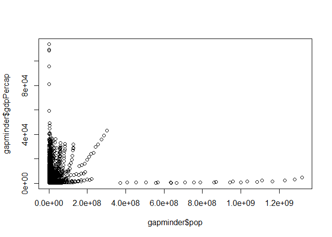

```r
plot(gapminder$pop, gapminder$gdpPercap)
```

Here is a scatterplot between time (measured in years on the x-axis) and GDP per capita (on the y-axis)

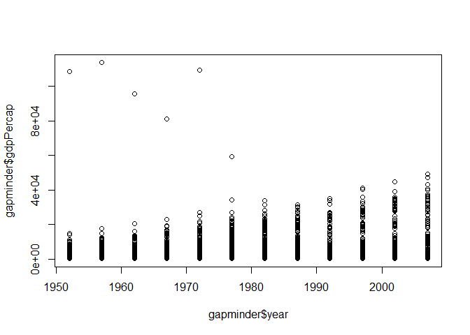

```r
plot(gapminder$year, gapminder$gdpPercap)
```

### Complex plots

If we want to be able to capture more complexity in our groups, we need to install the ggplot package using this command: install.packages(‘ggplot2’)

If the package is already installed, get access to it

```r
library(ggplot2)
```

Here we can visualize various continents by using colors.

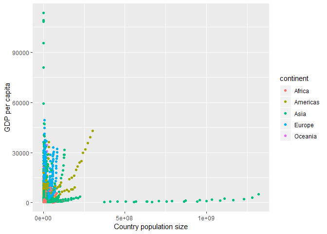

```r
ggplot(gapminder, aes(x=pop, y=gdpPercap, color=continent))+geom_point()+ xlab("Country population size") +
  ylab("GDP per capita")
```